# Homework 2: Housing Price

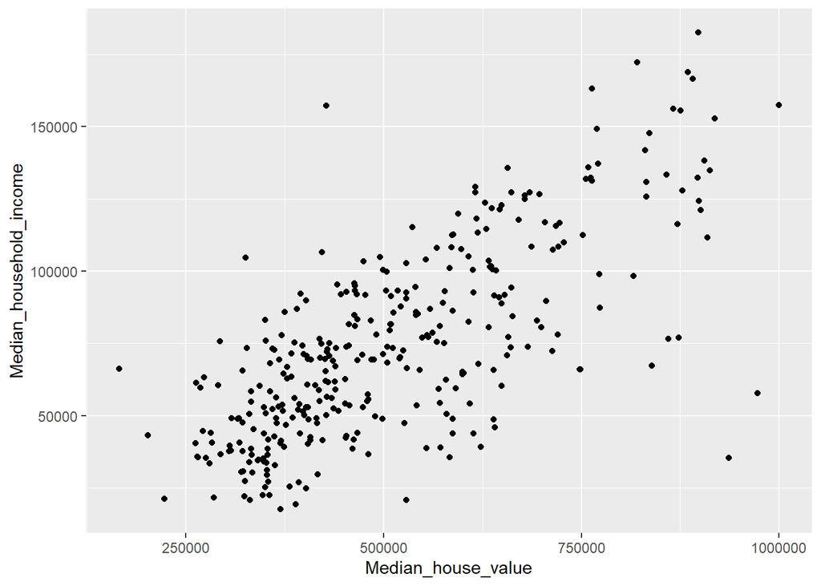

```r
ggplot(data = (ca_pa.omit %>%
filter(COUNTYFP==1,STATEFP==6) %>%     select(COUNTYFP,Median_house_value,Median_household_income))) +
  geom_point(aes(x = Median_house_value, y = Median_household_income))
```

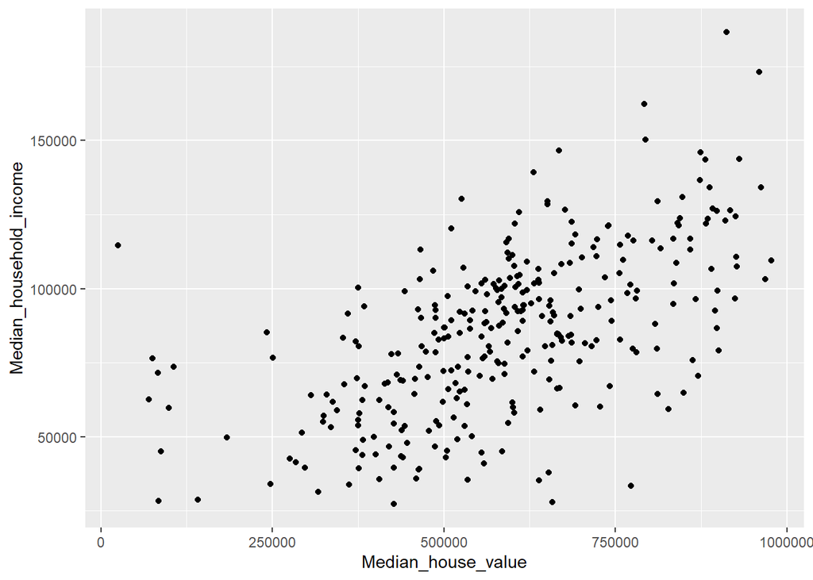

```r
ggplot(data = na.omit(ca_pa %>% filter(COUNTYFP==85,STATEFP==6) %>%     select(Median_house_value,Median_household_income))) +
  geom_point(aes(x = Median_house_value, y = Median_household_income))
```

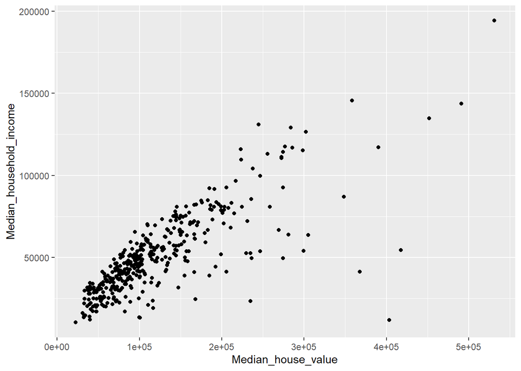

```r
ggplot(data = na.omit(ca_pa %>% filter(COUNTYFP==3,STATEFP==42) %>%     select(Median_house_value,Median_household_income))) +
  geom_point(aes(x = Median_house_value, y = Median_household_income))
```

MB.Ch1.11. Run the following code:

```
gender <- factor(c(rep("female", 91), rep("male", 92)))
table(gender)
gender <- factor(gender, levels=c("male", "female"))
table(gender)
gender <- factor(gender, levels=c("Male", "female"))
# Note the mistake: "Male" should be "male"
table(gender)
table(gender, exclude=NULL)
rm(gender)  # Remove gender
```

Explain the output from the successive uses of table().

MB.Ch1.18. The Rabbit data frame in the MASS library contains blood pressure change measurements on five rabbits (labeled as R1, R2, . . . ,R5) under various control and treatment conditions. Read the help file for more information. Use the unstack() function (three times) to convert Rabbit to the following form:

Treatment Dose R1 R2 R3 R4 R5

1 Control 6.25 0.50 1.00 0.75 1.25 1.5

2 Control 12.50 4.50 1.25 3.00 1.50 1.5

….

```r
Rabbit.1<-unstack(Rabbit,BPchange~Animal)
Dose<-unstack(Rabbit, Dose~Animal)[,1]
Treatment<-unstack(Rabbit, Treatment~Animal)[,1]
Rabbit.new<-data.frame(Treatment,Dose,Rabbit.1)
```